# Introdução a dataviz no R

## Atributos vs. Aesthetics

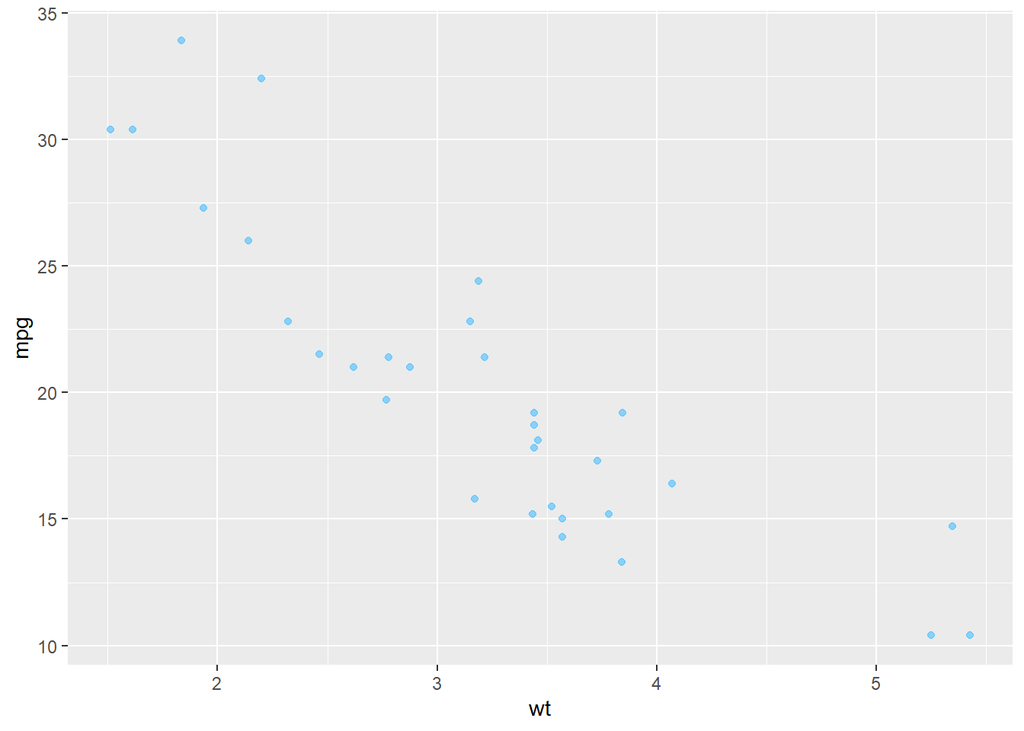

```r
# A hexadecimal color
my_blue <- "#4ABEFF"

ggplot(mtcars, aes(wt, mpg)) +
  # Set the point color and alpha
  geom_point(color = my_blue, alpha = 0.6)
```

Observe que o atributo é um valor constante que vale para todos os pontos e é colocado fora do aes().

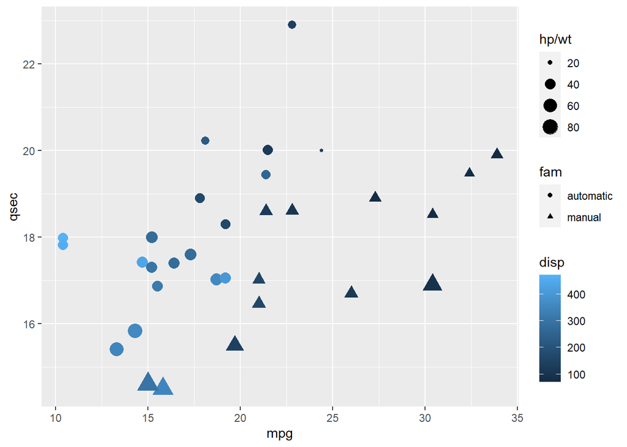

```r
# Using am as a factor
mtcars_mod <-
  mtcars %>%
  mutate(fam = factor(am),
         fcyl = factor(cyl))

levels(mtcars_mod$fam) <- c("automatic", "manual")

# 5 aesthetics: add a mapping of size to hp / wt
ggplot(mtcars_mod, aes(mpg, qsec, color = disp, shape = fam, size = hp/wt)) +
  geom_point()
```

## Positions

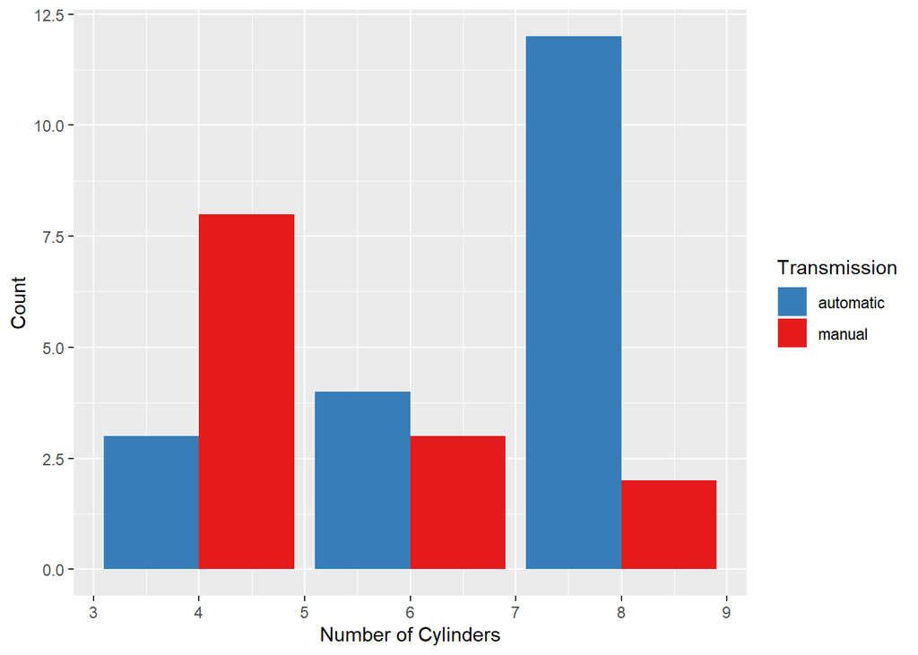

```r
palette <- c(automatic = "#377EB8", manual = "#E41A1C")

# Set the position
ggplot(mtcars_mod, aes(cyl, fill = fam)) +
  geom_bar(position = 'dodge') +
  labs(x = "Number of Cylinders", y = "Count")+
  scale_fill_manual("Transmission", values = palette)
```

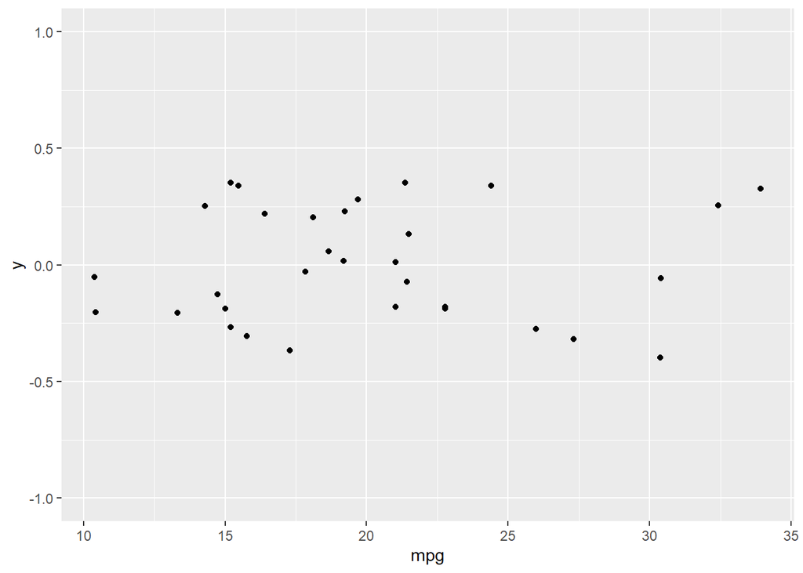

```r
# Plot 0 vs. mpg
ggplot(mtcars, aes(x=mpg, y=0)) +
  # Add jitter
  geom_point(position = 'jitter') +
  ylim(-1,1)
```

O que foi feito aqui? What is y?

## Aesthetics best practices

> Form follows functions

Function:

1. Primary: Accurate and efficient representations
2. Secondary: Visually, appealing, beautiful plots

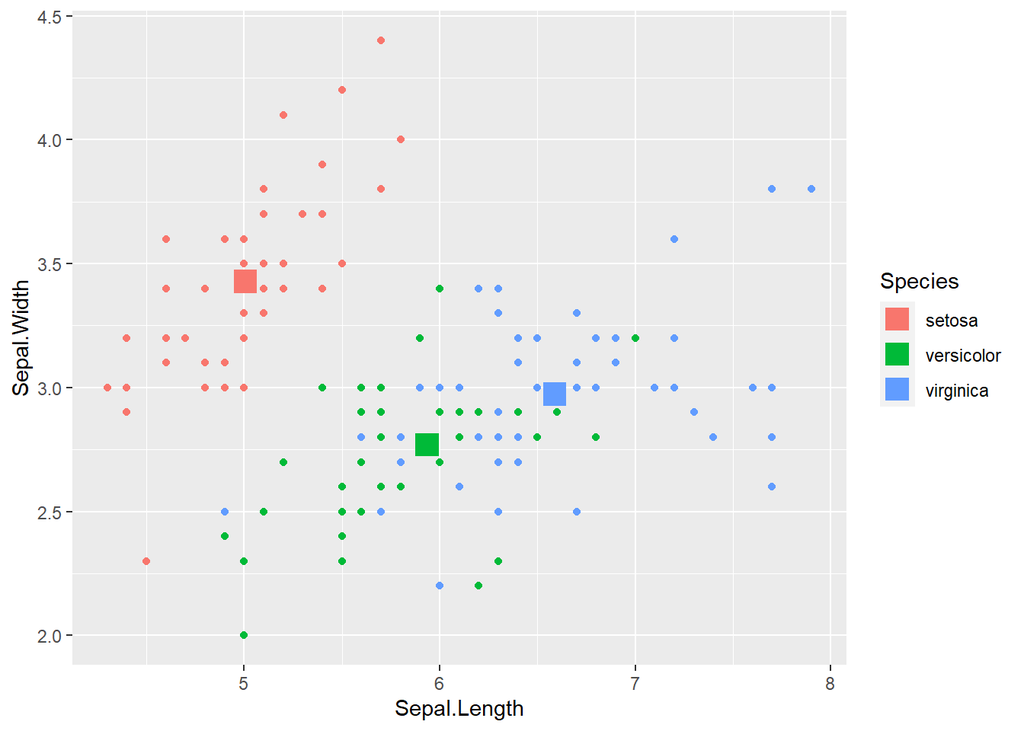

```r
iris %>%
  group_by(Species) %>%
  summarise_all(mean) -> iris.summary

ggplot(iris, aes(x = Sepal.Length, y = Sepal.Width, col = Species)) +
  # Inherits both data and aes from ggplot()
  geom_point() +
  # Different data, but inherited aes
  geom_point(data = iris.summary, shape = 15, size = 5)
```

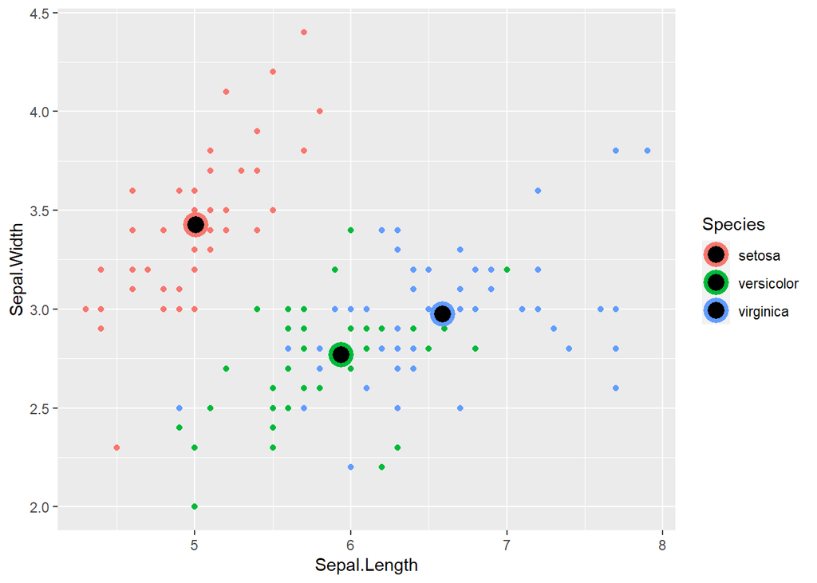

```r
ggplot(iris, aes(x = Sepal.Length, y = Sepal.Width, col = Species)) +   geom_point() +
  geom_point(data = iris.summary,
             shape = 21,
             size = 5,
             fill = "black",
             stroke = 2)
```

Veja os atributos do ‘shape’

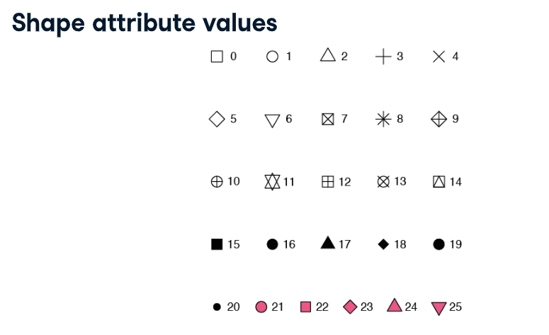

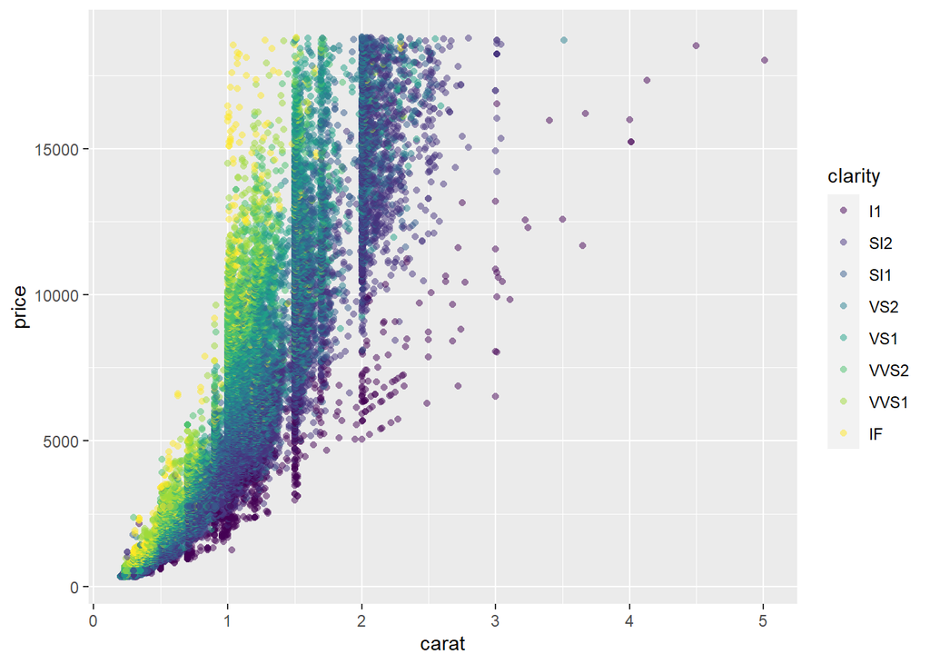

```r
# Plot price vs. carat, colored by clarity
plt_price_vs_carat_by_clarity <- ggplot(diamonds, aes(carat, price, color = clarity))

# Set transparency to 0.5 and use shape = 16
plt_price_vs_carat_by_clarity + geom_point(alpha = 0.5, shape = 16)
```

### Comparation of jitter and dodge

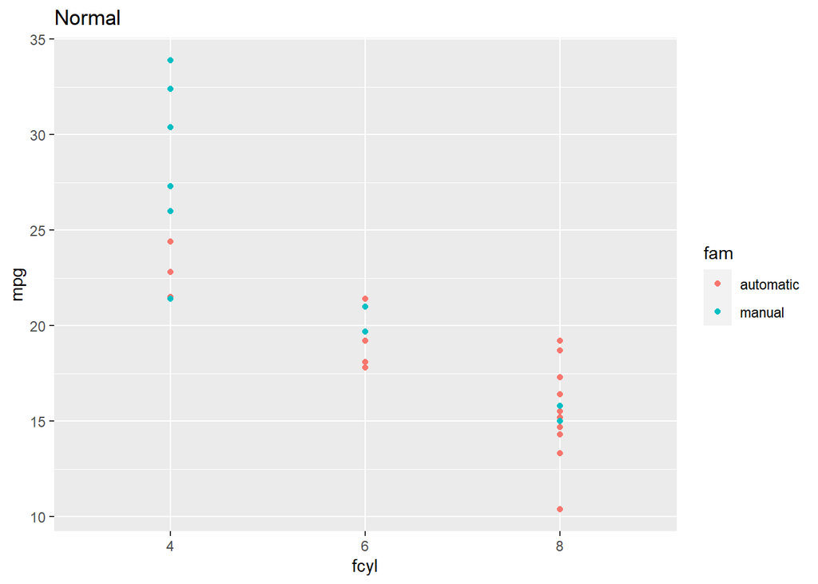

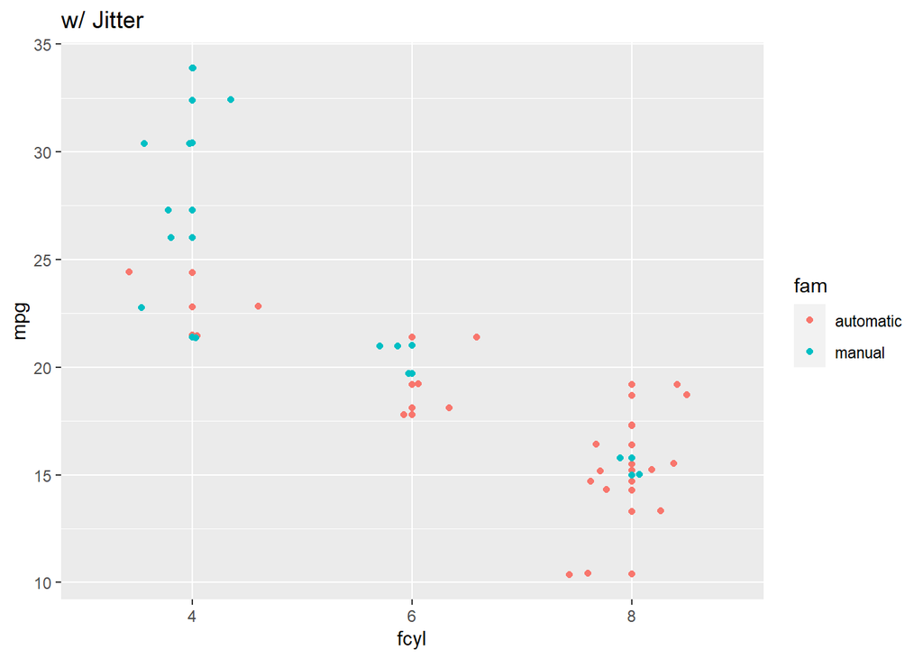

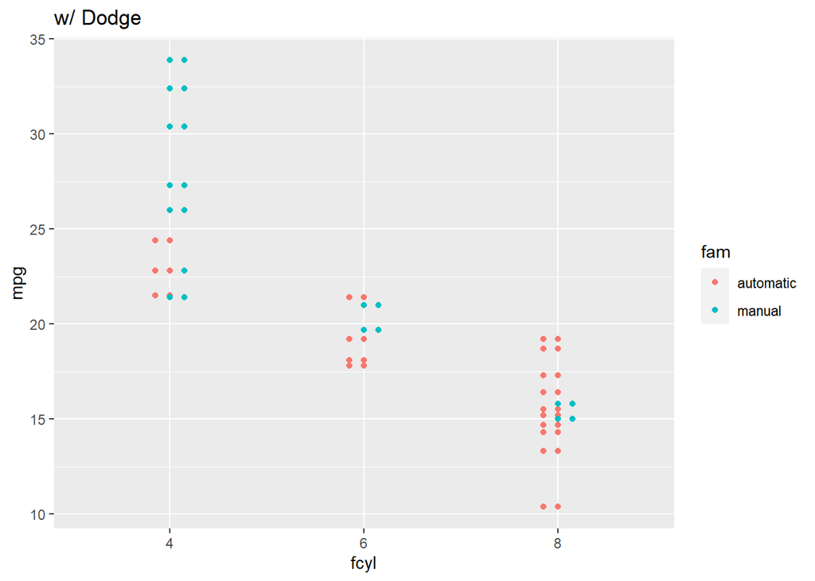

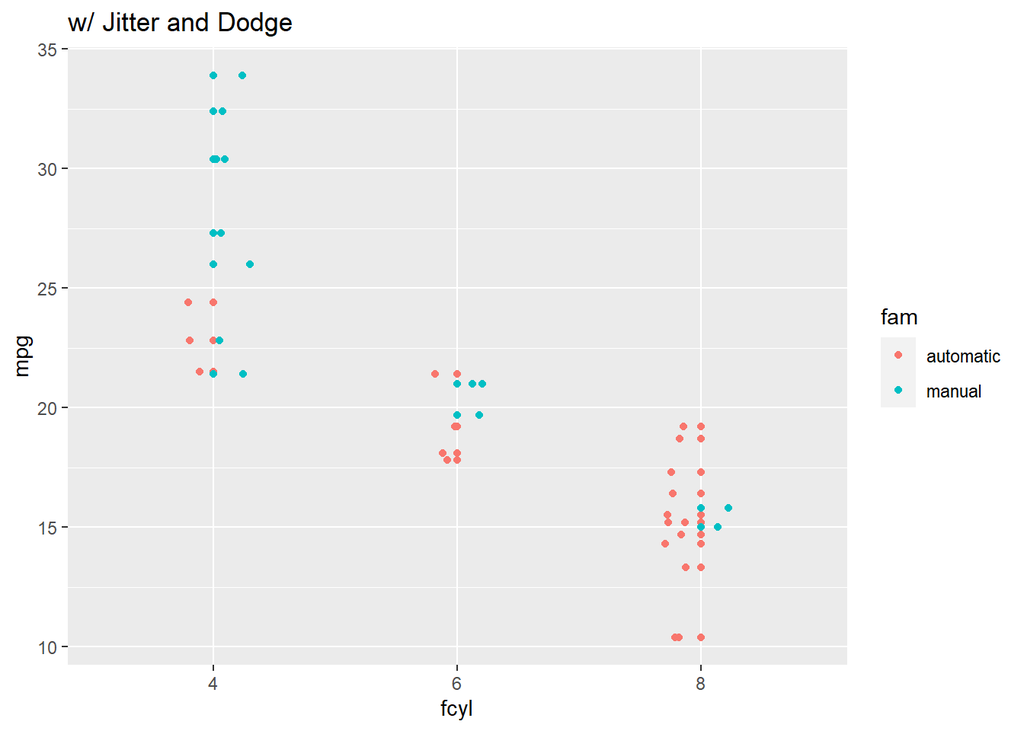

```r
par(mfrow=c(2,2))

# G1
# Plot base
plt_mpg_vs_fcyl_by_fam <-
ggplot(mtcars_mod, aes(fcyl, mpg, color = fam))

# Default points are shown for comparison
plt_mpg_vs_fcyl_by_fam <-
  plt_mpg_vs_fcyl_by_fam +
  geom_point()

# Show the graphic
plt_mpg_vs_fcyl_by_fam + ggtitle('Normal')

# G2
# Plot base
# Alter the point positions by jittering, width 0.3
plt_mpg_vs_fcyl_by_fam + geom_point(position = position_jitter(width = 0.3)) + ggtitle('w/ Jitter')

#G3
# Now dodge the point positions
plt_mpg_vs_fcyl_by_fam + geom_point(position = position_dodge(width=0.3)) + ggtitle('w/ Dodge')


#G4
# Now jitter and dodge the point positions
plt_mpg_vs_fcyl_by_fam + geom_point(position = position_jitterdodge(jitter.width = 0.3, dodge.width=0.3))  + ggtitle('w/ Jitter and Dodge')

par(mfrow=c(1,1))
```

Notice that **jitter** can be a geom itself (i.e. `geom_jitter()`), an argument in `geom_point()` (i.e. `position = "jitter"`), or a position function, (i.e. `position_jitter()`).

#### Podemos comparar os widths:

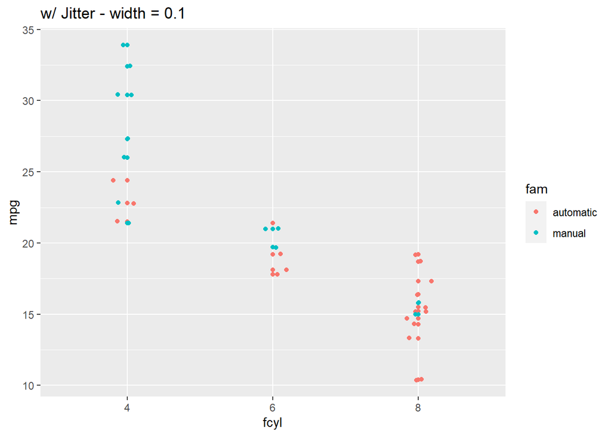

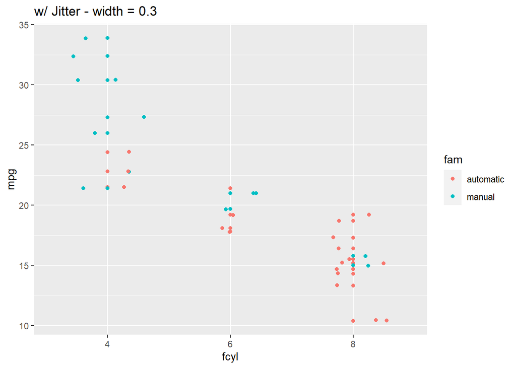

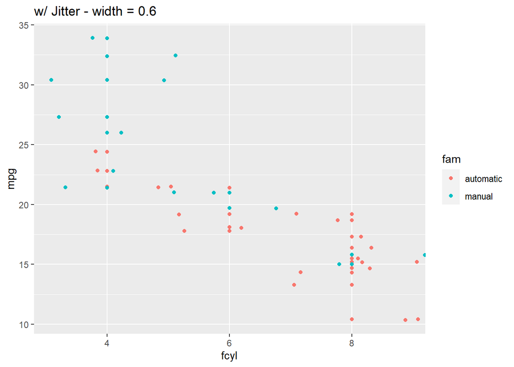

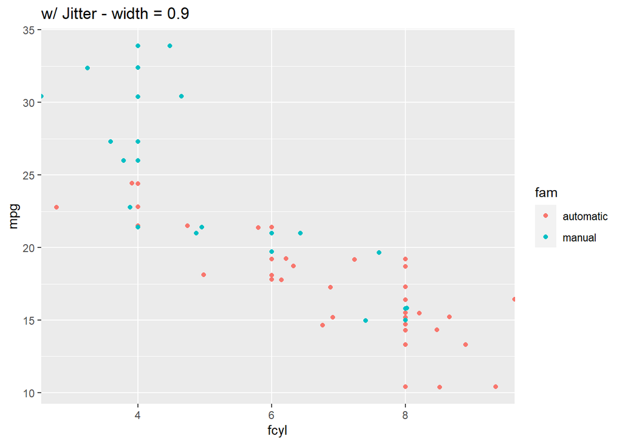

```r
par(mfrow=c(2,2))
# G2.1
# Plot base
# Alter the point positions by jittering, width 0.3
plt_mpg_vs_fcyl_by_fam + geom_point(position = position_jitter(width = 0.1)) + ggtitle('w/ Jitter - width = 0.1')

# G2.2
# Plot base
# Alter the point positions by jittering, width 0.3
plt_mpg_vs_fcyl_by_fam + geom_point(position = position_jitter(width = 0.3)) + ggtitle('w/ Jitter - width = 0.3')


# G2.3
# Plot base
# Alter the point positions by jittering, width 0.3
plt_mpg_vs_fcyl_by_fam + geom_point(position = position_jitter(width = 0.6)) + ggtitle('w/ Jitter - width = 0.6')

# G2.9
# Plot base
# Alter the point positions by jittering, width 0.3
plt_mpg_vs_fcyl_by_fam + geom_point(position = position_jitter(width = 0.9)) + ggtitle('w/ Jitter - width = 0.9')

par(mfrow=c(1,1))
```

Usando density:

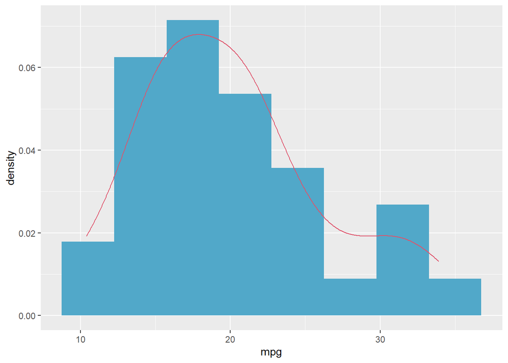

```r
datacamp_light_blue <- "#51A8C9"
# Using density
ggplot(mtcars, aes(mpg, y = ..density..)) +
  # Set the fill color to datacamp_light_blue
  geom_histogram(binwidth = 3.5, fill = datacamp_light_blue) +
  # In order to see density use:
  geom_density(lwd = 0.5,
               linetype = 1,
               colour = 2)
```